# cyclistic_case_study

Sameer

2025-10-31

### Setting Up Libraries

To begin the analysis, several R packages were loaded to simplify data cleaning, manipulation, and visualization tasks.  
The **tidyverse** package offers a unified collection of tools for data wrangling and plotting; **scales** helps format large numeric labels.

Together, these libraries create a strong foundation for reproducible data analysis within R Markdown.

```r
library(tidyverse)
library(scales)
```

### Data Source, Cleaning, and Aggregation

This analysis uses open-source data from the **Divvy Trip Data** portal provided by Lyft, available at  
https://divvy-tripdata.s3.amazonaws.com/index.html.

The dataset contains anonymized trip-level information from the Cyclistic bike-share program, covering **October 2024 to September 2025**.  
Each monthly file includes ride details such as `rideable_type`, `started_at`, `ended_at`, `start_lat`, `end_lat`, and user type (`member_casual`).

Before importing into R, all 12 months of data were **cleaned and aggregated using Power Query in Excel**.  
The cleaning process involved:

- Removing duplicate and incomplete records (e.g., missing station names or coordinates).
- Calculating ride duration from `started_at` and `ended_at` timestamps.
- Extracting temporal features such as **month**, **day of week**, and **hour**.
- Creating **ride length buckets** (e.g., 0–15, 15–30, 30–60 minutes) to group similar trips.
- Aggregating data by key attributes such as user type, ride type, and time intervals to reduce file size and improve processing speed.

The resulting aggregated dataset provides a comprehensive yet compact view of usage patterns suitable for exploratory analysis in R Markdown.

**Data Credit:**  
Data used in this analysis is made available by Lyft Inc. through the [Divvy Trip Data](https://divvy-tripdata.s3.amazonaws.com/index.html) platform under an open data license. All rights and ownership remain with the original provider.

### Importing the Aggregated Dataset

The aggregated dataset used in this analysis combines 12 months of Cyclistic trip data, previously cleaned and summarized in Excel Power Query.  
Each record represents a unique combination of user type, rideable type, month, day of week, hour, and ride length bucket, along with aggregated ride counts and average ride durations.

This structure significantly reduces data volume while preserving analytical depth, allowing efficient exploration of user behaviors and seasonal trends.

```r
data <- read_csv("C:/Users/Sameer/Downloads/Data Analysis/Google Data Analytics/Capstone Project/bike_ride_data.csv")
glimpse(data)
```

```
## Rows: 41,541
## Columns: 8
## $ member_type        <chr> "member", "member", "member", "member", "member", "…
## $ rideable_type      <chr> "classic_bike", "classic_bike", "classic_bike", "cl…
## $ month              <chr> "Oct", "Oct", "Oct", "Oct", "Oct", "Oct", "Oct", "O…
## $ day_of_week        <chr> "Sunday", "Sunday", "Sunday", "Sunday", "Sunday", "…
## $ hour               <dbl> 21, 3, 23, 15, 4, 8, 6, 20, 8, 9, 19, 15, 1, 16, 22…
## $ rIde_length_bucket <chr> "120+ mins", "120+ mins", "120+ mins", "120+ mins",…
## $ total_rides        <dbl> 1, 1, 1, 1, 1, 1, 1, 1, 1, 1, 1, 1, 1, 1, 1, 1, 1, …
## $ avg_ride_length    <dbl> 663, 245, 737, 136, 136, 159, 188, 996, 203, 566, 7…
```

### Data Sanity Checks

Before beginning the analysis, several data validation steps were performed: - Confirmed that only two **member types** (`member` and `casual`) exist. - Verified **rideable_type** contains two valid bike types (classic and electric). - Checked for outliers in `avg_ride_length` and `total_rides`. - Confirmed hourly values ranged correctly from 0–23.

This ensured data integrity and consistency for subsequent analysis.

```r
summary(data)
```

```
##  member_type        rideable_type         month           day_of_week
##  Length:41541       Length:41541       Length:41541       Length:41541
##  Class :character   Class :character   Class :character   Class :character
##  Mode  :character   Mode  :character   Mode  :character   Mode  :character
##
##
##
##       hour       rIde_length_bucket  total_rides     avg_ride_length
##  Min.   : 0.00   Length:41541       Min.   :   1.0   Min.   :   1.500
##  1st Qu.: 7.00   Class :character   1st Qu.:   6.0   1st Qu.:   9.241
##  Median :12.00   Mode  :character   Median :  35.0   Median :  21.280
##  Mean   :11.97                      Mean   : 130.9   Mean   :  57.133
##  3rd Qu.:18.00                      3rd Qu.: 154.0   3rd Qu.:  47.500
##  Max.   :23.00                      Max.   :3477.0   Max.   :1440.000
```

```r
n_distinct(data$member_type)
```

```
## [1] 2
```

```r
n_distinct(data$rideable_type)
```

```
## [1] 2
```

### Descriptive Analysis

The descriptive phase explores basic usage patterns and differences between members and casual riders. #### A. Total Rides by Member Type

This visualization reveals the overall ride volume distribution between user types.  
**Members** dominate total ridership, indicating consistent usage — likely for daily commuting or short trips.  
**Casual riders**, while fewer, represent significant activity that could be converted into memberships with the right incentives.

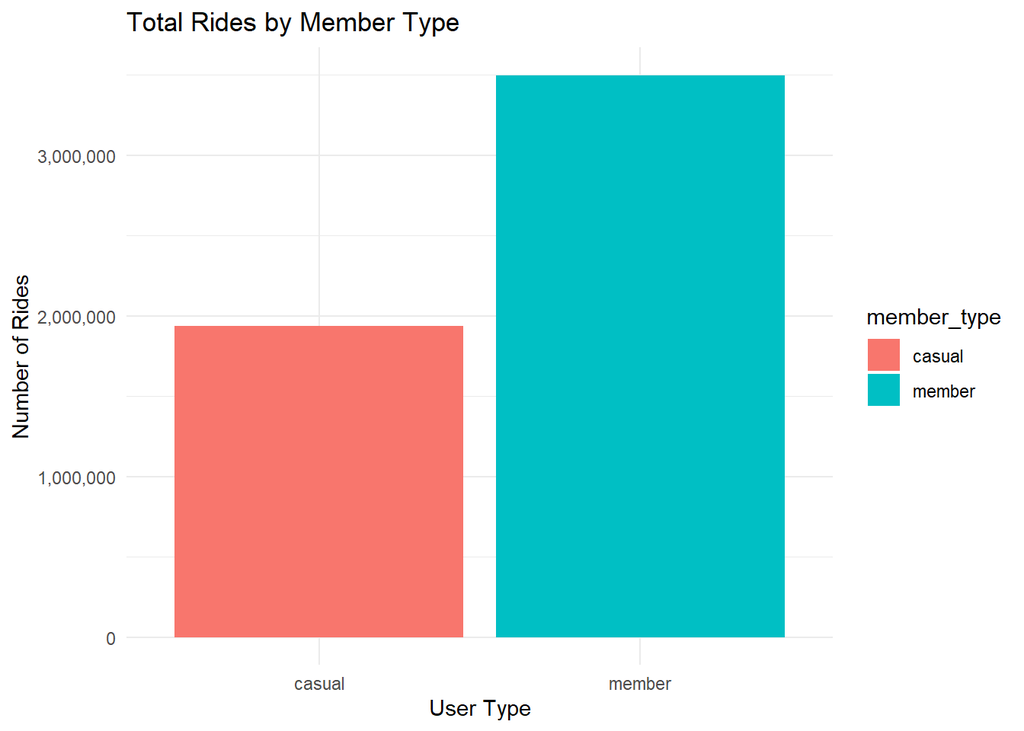

```r
data %>%
  group_by(member_type) %>%
  summarise(total_rides = sum(total_rides)) %>%
  ggplot(aes(x = member_type, y = total_rides, fill = member_type)) +
  geom_bar(stat = "identity") + scale_y_continuous(labels = comma) +
  labs(title = "Total Rides by Member Type", x = "User Type", y = "Number of Rides") +
  theme_minimal()
```

#### B. Average Ride Length by Member Type

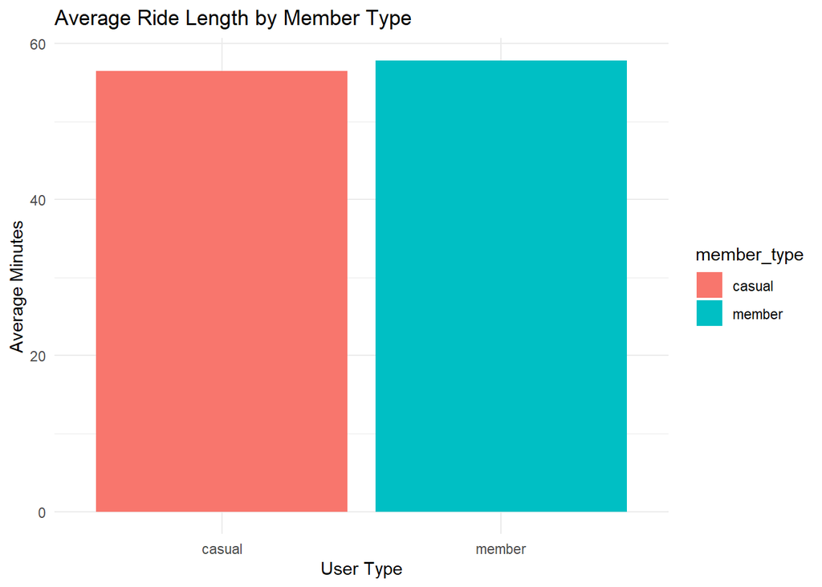

```r
data %>%
  group_by(member_type) %>%
  summarise(avg_length = mean(avg_ride_length)) %>%
  ggplot(aes(x = member_type, y = avg_length, fill = member_type)) +
  geom_col() +
  labs(title = "Average Ride Length by Member Type", x = "User Type", y = "Average Minutes") +
  theme_minimal()
```

### Time-Based Trends

#### A. Rides by Day of Week

Weekday vs. weekend analysis highlights behavioral contrasts: - **Members** have higher ridership on weekdays, suggesting routine or commute-based usage. - **Casual riders** peak on weekends, reflecting recreational patterns.

This clear separation reinforces the notion that Cyclistic’s user base splits between commuters and leisure users.

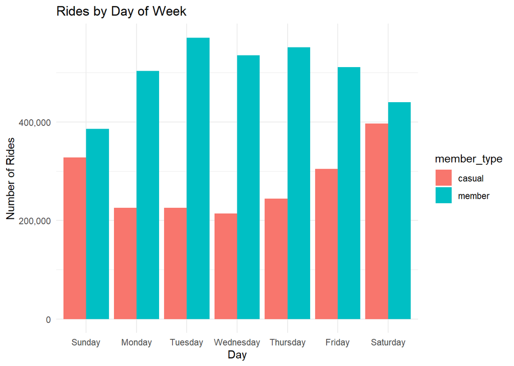

```r
data %>%
  group_by(member_type, day_of_week) %>%
  summarise(total_rides = sum(total_rides)) %>%
  ggplot(aes(x = fct_relevel(day_of_week, c("Sunday","Monday","Tuesday","Wednesday","Thursday","Friday","Saturday")),
             y = total_rides, fill = member_type)) +
  geom_col(position = "dodge") + scale_y_continuous(labels = comma) +
  labs(title = "Rides by Day of Week", x = "Day", y = "Number of Rides") +
  theme_minimal()
```

#### B. Rides by Hour

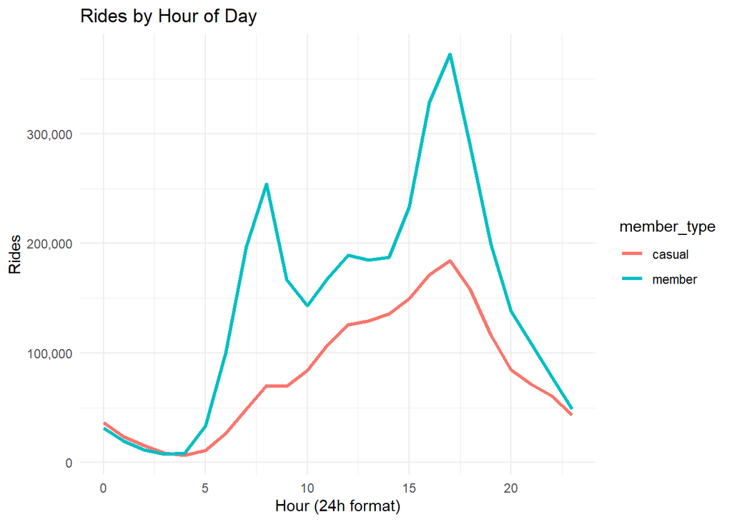

```r
data %>%
  group_by(member_type, hour) %>%
  summarise(total_rides = sum(total_rides)) %>%
  ggplot(aes(x = hour, y = total_rides, color = member_type)) +
  geom_line(size = 1.2) + scale_y_continuous(labels = comma) +
  labs(title = "Rides by Hour of Day", x = "Hour (24h format)", y = "Rides") +
  theme_minimal()
```

### Seasonal Trends

This visualization explores ridership patterns across months.  
Both user types show strong seasonality, with ride counts peaking during **summer months** (June–August) and dropping significantly in **winter**.  
Casual riders display more pronounced seasonality — reflecting fair-weather leisure rides — while members maintain steadier engagement year-round.

Understanding these trends helps Cyclistic plan maintenance, marketing campaigns, and membership drives in alignment with seasonal fluctuations.

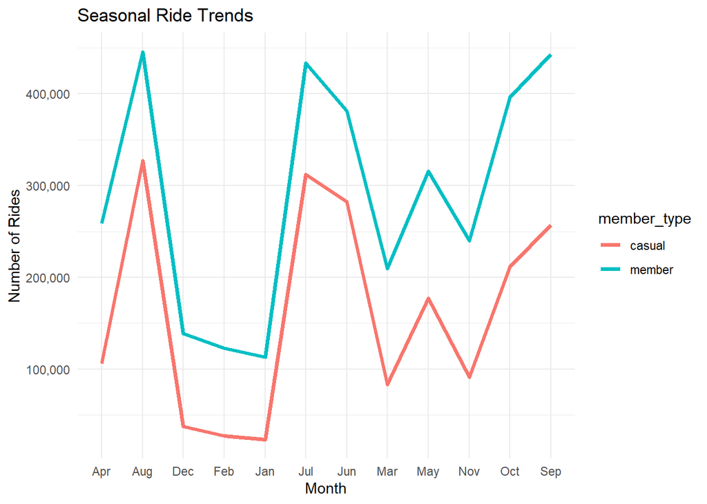

```r
data %>%
  group_by(member_type, month) %>%
  summarise(total_rides = sum(total_rides)) %>%
  ggplot(aes(x = month, y = total_rides, group = member_type, color = member_type)) +
  geom_line(size = 1.3) + scale_y_continuous(labels = comma) +
  labs(title = "Seasonal Ride Trends", x = "Month", y = "Number of Rides") +
  theme_minimal()
```

### Insights and Discussion

**Overall Interpretation:**  
Cyclistic’s dual audience reflects two distinct behavioral groups: - **Members = Consistency & Commuting** - **Casuals = Leisure & Exploration**

This segmentation underscores the importance of **customized marketing and operational strategies** to drive membership growth and retention.

### Recommendations

By tailoring its strategy to these insights, Cyclistic can increase overall engagement and encourage casual riders to become long-term members.